# R Beginners Course

Exercise 1 - Solved

## Welcome

Welcome to the first tutorial of the R Beginners Course of Spatial analysis. We hope that you are ready to try some things out!

## Outline

This tutorial is composed by two exercises:

- Populations in Finland and Sweden
- How much does it rain in Colombian cities?

After the completion of this tutorial you will be able to import, modify, and export data files and extract information from gridded datasets.

## Popultions in Finland and Sweden

First we have to set the paths to the data.

```r
finland_path <- "C:/Users/R1_Exercise/Data/Part_1/Finland.csv"
sweden_path  <- "C:/Users/R1_Exercise/Data/Part_1/Sweden.csv"
```

Now we can read the files with the read.csv function.

```r
finland <- read.csv(finland_path)
sweden  <- read.csv(sweden_path)
```

We will add columns to both data frames that indicate the respective countries.

```r
finland$Country <- rep("Finland", times = nrow(finland))
sweden$Country  <- rep("Sweden", times = nrow(sweden))
```

Now we will use the *rbind* function to combine both data frames into a new one (**comb_df**).

```r
comb_df <- rbind(finland, sweden)
```

To order the resulting data frame from the largest to the smallest population, we will use the order function. This function will retrieve the positions of the elements according to population.

```r
new_order <- order(comb_df$Population, decreasing = TRUE)
print(new_order)
```

```
##   [1] 164   6  86 128   2  53 179  59  37  55 121 142 185  94 137  99  15 176
##  [19] 127  27  25  71  96  77 135  89  84 158 167 187  73 104  90 110 114  39
##  [37] 161  24  98 126  14 160 155 169  28 100 132  57   3 103 182 146  50 138
##  [55]  46  87  81 172 140 156 174 143  34 166  72  23  93  47  40 153 173 118
##  [73]  22 178 113 145   8 116  76  79  31 171 183  13 134 117  36  66 149  64
##  [91] 119 181  21 148 152  44  56  92  97 165 188  20  17 186 130 105 184  78
## [109] 180  16  35  62  80  49  74 101 106  18  63 136 190 102 177  85 150  61
## [127]  75 141  45 122  69 131  43 189  95 144 163  70 125  10 108 115  67 162
## [145] 157  91 124 175  41 129  48 111  42 120  29   7  68 151 168 107 147  88
## [163] 112  82  54  51   9 170  52  58  32  19  26 133  60 139  65  12   4  30
## [181] 154  11 159 123   1   5 109  38  83  33
```

Afterwards, we have to order the data frame according to these positions:

```r
comb_df <- comb_df[new_order, ]
head(comb_df)
```

```
##                            Name Population Country
## 164                   Stockholm     975551  Sweden
## 6     Helsinki\xa0(Helsingfors)     653835 Finland
## 86  G\xf6teborg\xa0[Gothenburg]     583056  Sweden
## 128                    Malm\xf6     347949  Sweden
## 2               Espoo\xa0(Esbo)     289731 Finland
## 53                      Tampere     238140 Finland
```

```r
tail(comb_df)
```

```
##             Name Population Country
## 1      Aanekoski      18765 Finland
## 5        Heinola      18667 Finland
## 109     Kramfors      18133  Sweden
## 38    Pieksamaki      17682 Finland
## 83  G\xe4llivare      17462  Sweden
## 33     Mariehamn      11679 Finland
```

Finally, we can export the data frame as a CSV file.

```r
write.csv(comb_df, "C:/Users/R1_Exercise/Data/Part_1/Output_data.csv")
```

## How much does it rain in Colombian cities?

In the CHIRPS_monthly folder, we have monthly precipitation rasters from 2000 to 2003. We want to examine the difference in monthly precipitation between Bogota (4.7, -74.1) and Medellin (6.2, -75.6). The shapefile for Colombia is in the folder Colombia.

1. Plot the locations of the two cities along with the first monthly precipitation raster, masked to the extent of Colombia.
2. Extract the monthly precipitation time series for the two cities.
3. Plot the two time series as a line chart.
4. Calculate the differences in monthly precipitation between the two cities.

First, we have to load the packages that we will use.

```r
library(terra)
library(sf)
```

Next, we will set the paths to the data.

```r
chirps_path   <- "C:/Users/Data/Part_2/CHIRPS_monthly"
colombia_path <- "C:/Users/Data/Part_2/Colombia/COL_adm0.shp"
```

We have to read the Colombian shapefile and list the CHIRPS files.

```r
colombia     <- vect(colombia_path)
chirps_files <- list.files(chirps_path, full.names = TRUE)
```

Let’s plot the shapefile:

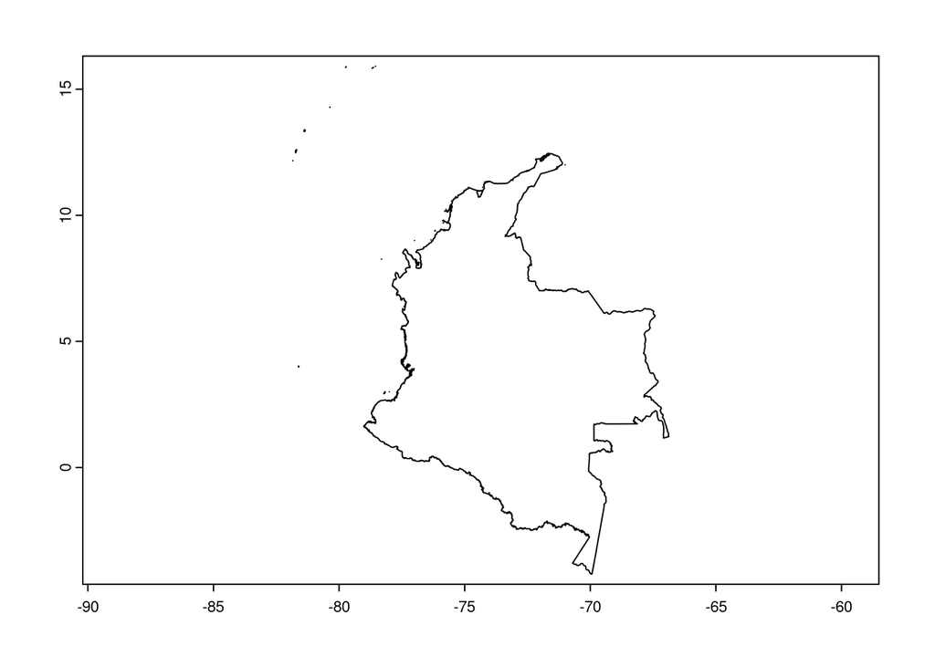

```r
plot(colombia, axes = TRUE)
```

Create a data frame with the location of the cities and convert it to a spatial object.

```r
cities <- data.frame(Name = c("Bogota", "Medellin"),
                     lon = c(-74.1, -75.6),
                     lat = c(4.7, 6.2))
cities <- st_as_sf(cities, coords = c("lon", "lat"))
cities <- vect(cities)
```

Now we will *stack* the CHIRPS files and *crop* them to the study area extent.

```r
chirps_stack <- rast(chirps_files)
chirps_stack <- crop(chirps_stack, colombia, snap = "OUT")
```

**Solution A**

Once we have the CHIRPS stack cropped to the spatial extent of Colombia, we can store the first CHIRPS file as an object and then mask it using the shapefile of the study area.

```r
jan_2000 <- chirps_stack[[1]]
jan_2000 <- mask(jan_2000, colombia)
```

Now, we can plot the raster along with the locations of Bogota and Medellin.

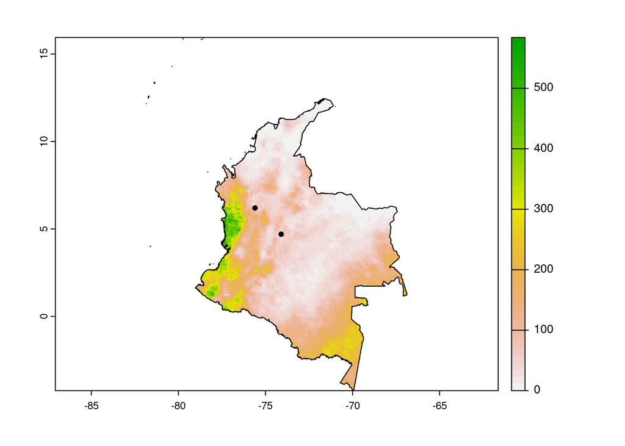

```r
plot(jan_2000)
lines(colombia)
points(cities)
```

**Solution B**

Use the extract function to obtain the time series for both cities. As a result, we will obtain a data frame with 2 rows and 49 columns. The first row will contain the data for Bogota, while the second will contain the data for Medellin.

```r
p_cities <- terra::extract(chirps_stack, cities)
dim(p_cities)
```

```
## [1]  2 49
```

```r
# Here, we separate the data for both cities excluding the first column (the one of the ID)
bogota_p   <- as.numeric(p_cities[1, -1 ])
medellin_p <- as.numeric(p_cities[2, -1 ])
print(bogota_p)
```

```
##  [1]  26.01648  43.87797  54.19332  53.78993  73.42372  58.97512  64.15267
##  [8]  52.20889  81.87256  72.41448  41.31596  23.27617  13.96754  24.57698
## [15]  52.80560  29.72800  77.57053  46.98207  38.77486  30.62109  61.37615
## [22]  58.45210  58.78082  43.50504  13.99164  13.99624  63.66564 119.72684
## [29]  84.95819  76.46921  39.07662  42.53190  43.68065  79.46979  31.62677
## [36]  38.64576  10.15345  22.97553  56.89735  94.54290  39.24740  62.44681
## [43]  43.23598  37.36733  47.66502 101.52205  82.42000  39.18044
```

```r
print(medellin_p)
```

```
##  [1]  80.65581 142.75757 145.17582 201.17267 272.66738 266.31411 199.57352
##  [8] 170.04138 284.45867 254.67384 131.80861 129.35348  85.39810  70.93958
## [15] 166.66690 126.14707 162.60637 118.08762 154.77400  40.00353 219.03648
## [22] 267.32960 174.36598 127.56710  44.92212  66.79132 138.17970 270.20089
## [29] 216.79399 143.26768  96.01857  87.06222 151.01849 269.41480 137.76650
## [36] 127.90530  22.06218 105.67618 129.25038 210.72907 190.70939 242.21506
## [43] 100.04607 182.19070 191.23021 289.52303 214.97617  95.93860
```

**Solution C**

To plot the two time series as a line chart:

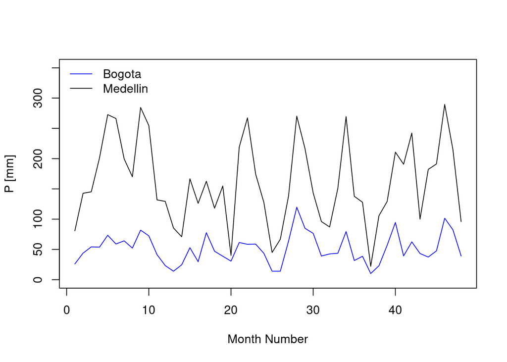

```r
plot(bogota_p, type = "l", col = "blue", ylim = c(0, 350),
     xlab = "Month Number", ylab = "P [mm]")
lines(medellin_p, col = "black")
legend("topleft", c("Bogota", "Medellin"), lty = 1, col = c("blue", "black"), bty = "n")
```

**Solution D**

To calculate the differences in monthly precipitation between the two cities, we will create first a vector with the dates.

```r
dates <- substr(names(chirps_stack), 15, 21)
```

We can create a summary data frame with the dates and the precipitation time series for both cities.

```r
p_summary <- data.frame(Dates = dates, Bogota = bogota_p, Medellin = medellin_p)
head(p_summary)
```

```
##     Dates   Bogota  Medellin
## 1 2000-01 26.01648  80.65581
## 2 2000-02 43.87797 142.75757
## 3 2000-03 54.19332 145.17582
## 4 2000-04 53.78993 201.17267
## 5 2000-05 73.42372 272.66738
## 6 2000-06 58.97512 266.31411
```

Now, we calculate the difference in monthly precipitation between the two cities.

```r
p_summary$Difference <- p_summary$Medellin - p_summary$Bogota
head(p_summary)
```

```
##     Dates   Bogota  Medellin Difference
## 1 2000-01 26.01648  80.65581   54.63933
## 2 2000-02 43.87797 142.75757   98.87960
## 3 2000-03 54.19332 145.17582   90.98249
## 4 2000-04 53.78993 201.17267  147.38274
## 5 2000-05 73.42372 272.66738  199.24367
## 6 2000-06 58.97512 266.31411  207.33899
```